# Classifying Heart Disease with Decision Trees

We will be using a database with 297 datapoints and the following attributes:

1. age
2. sex
3. chest pain type (4 values)
4. resting blood pressure
5. serum cholestoral in mg/dl
6. fasting blood sugar > 120 mg/dl
7. resting electrocardiographic results (values 0,1,2)
8. maximum heart rate achieved
9. exercise induced angina
10. oldpeak = ST depression induced by exercise relative to rest
11. the slope of the peak exercise ST segment
12. number of major vessels (0-3) colored by flourosopy
13. thal: 3 = normal; 6 = fixed defect; 7 = reversable defect
14. output parameter, which describes whether a heart disease is diagnosed (value 1) or not (value 0)

```python
import pandas as pd
import numpy as np
import matplotlib.pyplot as plt

from sklearn import tree
from sklearn.utils import shuffle
from sklearn.tree import DecisionTreeClassifier, export_graphviz
from sklearn.metrics import accuracy_score
from sklearn.model_selection import GridSearchCV, StratifiedKFold

import seaborn as sns
```

```python
# load the data

df =  pd.read_csv('heart.csv',names = ['age','sex','cp','trestbps','chol','fbs','restecg','thalach','exang','oldpeak','slope','ca','thal','target'])
df.head()
```

|  | age | sex | cp | trestbps | chol | fbs | restecg | thalach | exang | oldpeak | slope | ca | thal | target |
| --- | --- | --- | --- | --- | --- | --- | --- | --- | --- | --- | --- | --- | --- | --- |
| 0 | 63.0 | 1.0 | 1.0 | 145.0 | 233.0 | 1.0 | 2.0 | 150.0 | 0.0 | 2.3 | 3.0 | 0.0 | 6.0 | 0 |
| 1 | 67.0 | 1.0 | 4.0 | 160.0 | 286.0 | 0.0 | 2.0 | 108.0 | 1.0 | 1.5 | 2.0 | 3.0 | 3.0 | 1 |
| 2 | 67.0 | 1.0 | 4.0 | 120.0 | 229.0 | 0.0 | 2.0 | 129.0 | 1.0 | 2.6 | 2.0 | 2.0 | 7.0 | 1 |
| 3 | 37.0 | 1.0 | 3.0 | 130.0 | 250.0 | 0.0 | 0.0 | 187.0 | 0.0 | 3.5 | 3.0 | 0.0 | 3.0 | 0 |
| 4 | 41.0 | 0.0 | 2.0 | 130.0 | 204.0 | 0.0 | 2.0 | 172.0 | 0.0 | 1.4 | 1.0 | 0.0 | 3.0 | 0 |

```python
df.describe()
```

|  | age | sex | cp | trestbps | chol | fbs | restecg | thalach | exang | oldpeak | slope | ca | thal | target |
| --- | --- | --- | --- | --- | --- | --- | --- | --- | --- | --- | --- | --- | --- | --- |
| count | 297.000000 | 297.000000 | 297.000000 | 297.000000 | 297.000000 | 297.000000 | 297.000000 | 297.000000 | 297.000000 | 297.000000 | 297.000000 | 297.000000 | 297.000000 | 297.000000 |
| mean | 54.542088 | 0.676768 | 3.158249 | 131.693603 | 247.350168 | 0.144781 | 0.996633 | 149.599327 | 0.326599 | 1.055556 | 1.602694 | 0.676768 | 4.730640 | 0.461279 |
| std | 9.049736 | 0.468500 | 0.964859 | 17.762806 | 51.997583 | 0.352474 | 0.994914 | 22.941562 | 0.469761 | 1.166123 | 0.618187 | 0.938965 | 1.938629 | 0.499340 |
| min | 29.000000 | 0.000000 | 1.000000 | 94.000000 | 126.000000 | 0.000000 | 0.000000 | 71.000000 | 0.000000 | 0.000000 | 1.000000 | 0.000000 | 3.000000 | 0.000000 |
| 25% | 48.000000 | 0.000000 | 3.000000 | 120.000000 | 211.000000 | 0.000000 | 0.000000 | 133.000000 | 0.000000 | 0.000000 | 1.000000 | 0.000000 | 3.000000 | 0.000000 |
| 50% | 56.000000 | 1.000000 | 3.000000 | 130.000000 | 243.000000 | 0.000000 | 1.000000 | 153.000000 | 0.000000 | 0.800000 | 2.000000 | 0.000000 | 3.000000 | 0.000000 |
| 75% | 61.000000 | 1.000000 | 4.000000 | 140.000000 | 276.000000 | 0.000000 | 2.000000 | 166.000000 | 1.000000 | 1.600000 | 2.000000 | 1.000000 | 7.000000 | 1.000000 |
| max | 77.000000 | 1.000000 | 4.000000 | 200.000000 | 564.000000 | 1.000000 | 2.000000 | 202.000000 | 1.000000 | 6.200000 | 3.000000 | 3.000000 | 7.000000 | 1.000000 |

Decision Tree is not a similarity-based algorithm, but an **information-based algorithm**, hence there is no need to scale the data.

```python
df.info()
```

```
<class 'pandas.core.frame.DataFrame'>
Int64Index: 297 entries, 0 to 301
Data columns (total 14 columns):
 #   Column    Non-Null Count  Dtype
---  ------    --------------  -----
 0   age       297 non-null    float64
 1   sex       297 non-null    float64
 2   cp        297 non-null    float64
 3   trestbps  297 non-null    float64
 4   chol      297 non-null    float64
 5   fbs       297 non-null    float64
 6   restecg   297 non-null    float64
 7   thalach   297 non-null    float64
 8   exang     297 non-null    float64
 9   oldpeak   297 non-null    float64
 10  slope     297 non-null    float64
 11  ca        297 non-null    float64
 12  thal      297 non-null    float64
 13  target    297 non-null    int64
dtypes: float64(13), int64(1)
memory usage: 34.8 KB
```

```python
df.groupby('target').mean()
```

| target | age | sex | cp | trestbps | chol | fbs | restecg | thalach | exang | oldpeak | slope | ca | thal |
| --- | --- | --- | --- | --- | --- | --- | --- | --- | --- | --- | --- | --- | --- |
| 0 | 52.643750 | 0.556250 | 2.793750 | 129.175000 | 243.493750 | 0.143750 | 0.843750 | 158.581250 | 0.143750 | 0.598750 | 1.412500 | 0.275000 | 3.787500 |
| 1 | 56.759124 | 0.817518 | 3.583942 | 134.635036 | 251.854015 | 0.145985 | 1.175182 | 139.109489 | 0.540146 | 1.589051 | 1.824818 | 1.145985 | 5.832117 |

By grouping by our target variable and taking the average of each attribute, we can see there are some noticeable differences between people with a diagnosed heart disease and without.

We can try to visualize these distribution differences with pairplots and using as color hue our target variable

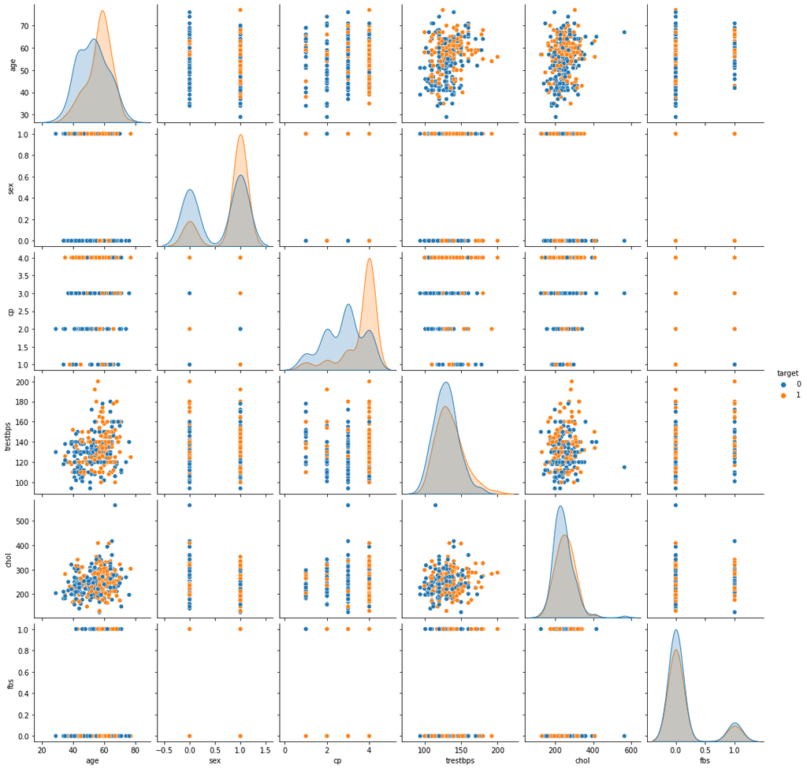

```python
sns.pairplot(df[['age','sex','cp','trestbps','chol','fbs','target']], hue="target")
```

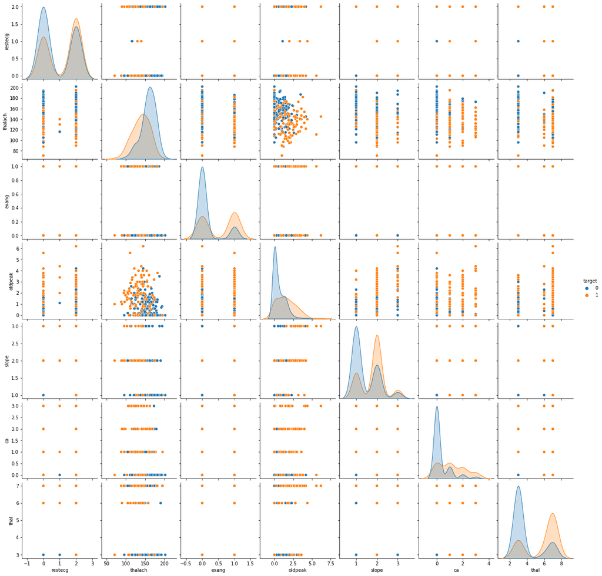

```python
sns.pairplot(df[['restecg','thalach','exang','oldpeak','slope','ca','thal','target']], hue="target")
```

### Shuffle data and split between train (70) and test (30) sets

```python
# shuffle
df = shuffle(df).reset_index(drop=True)

# divide attributes between output variable (y) and explanatory variables (x)

df_x = df.drop(['target'], axis=1)
df_y = df['target']
```

```python
# split between traing and test sets

from sklearn.model_selection import train_test_split

X_train, X_test, y_train, y_test = train_test_split(df_x, df_y, test_size=0.3, random_state=1)
```

### Train a decission tree and check performance to get a benchmark

```python
# fit decission tree on train set

dtc = DecisionTreeClassifier()
dtc.fit(X_train, y_train)
```

```
DecisionTreeClassifier()
```

```python
# get performance of our decission tree with the test set

prediction = dtc.predict(X_test)

#Score

score_tree = accuracy_score(y_test, prediction)

print("Accuracy score: " + str( score_tree))
```

```
Accuracy score: 0.7444444444444445
```

```
[Text(0.5431034482758621, 0.9, 'X[2] <= 3.5\ngini = 0.495\nsamples = 207\nvalue = [114, 93]'),
```

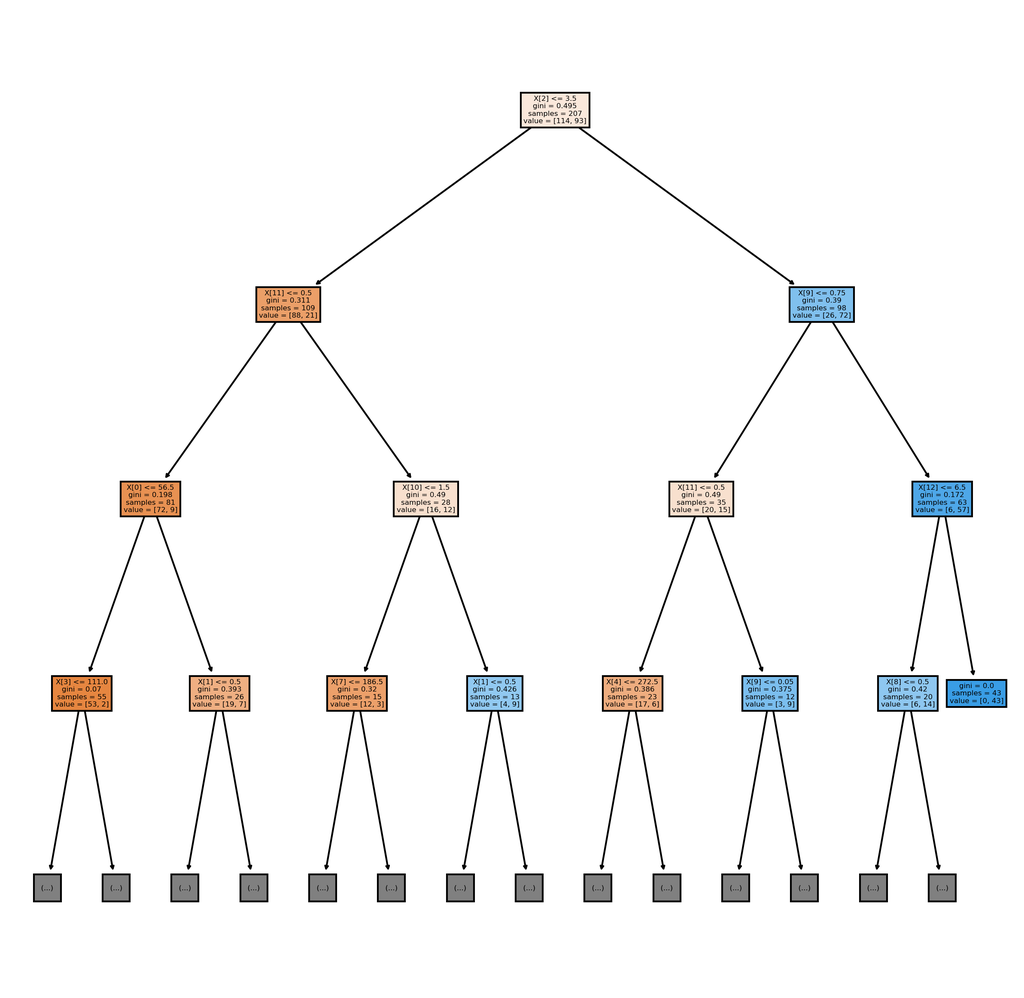

```python
# visualize decission tree

fig, axes = plt.subplots(nrows = 1,ncols = 1,figsize = (10,10), dpi=300)
tree.plot_tree(dtc, filled=True,max_depth=3)
```

The tree seems to be too long, this could create a problem of overfitting. We will try to change some parameters and to "prune" it to make it shorter

## Improving decision tree

We will be trying different criterions and we will prune the tree to improve accuracy

```python
### try differents criterions to measure the quality of the split

# gini criterion
dtc = DecisionTreeClassifier(criterion='gini')
dtc.fit(X_train, y_train)
pred = dtc.predict(X_test)
print('Criterion = gini', accuracy_score(y_test, pred))

# entropy criterion
dtc = DecisionTreeClassifier(criterion='entropy')
dtc.fit(X_train, y_train)
pred = dtc.predict(X_test)
print('Criterion = entropy', accuracy_score(y_test, pred))
```

```
Criterion = gini 0.7444444444444445
Criterion = entropy 0.7222222222222222
```

**Gini criterion** gives us a higher accuracy

To choose the best hyperparameters ('max_depth' and 'min_samples_leaf') we will be using **GridSearch**.

```python
# We will vary hyperparameters from 2 to 10
best_parameters = {'max_depth': np.arange(2,11), 'min_samples_leaf': np.arange(2,11)}

# choose gini criterion
dtc = DecisionTreeClassifier(criterion='entropy')

model = GridSearchCV(estimator=dtc, param_grid=best_parameters, n_jobs=-1, verbose=1, cv=StratifiedKFold(n_splits=3, shuffle=True, random_state=17))
model.fit(X_train, y_train)
```

```
Fitting 3 folds for each of 81 candidates, totalling 243 fits
```

```
GridSearchCV(cv=StratifiedKFold(n_splits=3, random_state=17, shuffle=True),
             estimator=DecisionTreeClassifier(criterion='entropy'), n_jobs=-1,
             param_grid={'max_depth': array([ 2,  3,  4,  5,  6,  7,  8,  9, 10]),
                         'min_samples_leaf': array([ 2,  3,  4,  5,  6,  7,  8,  9, 10])},
             verbose=1)
```

```python
# get best parameters
model.best_params_
```

```
{'max_depth': 3, 'min_samples_leaf': 7}
```

```python
# check improved accuracy with new hyperparameters

pred = model.predict(X_test)
accuracy_score(y_test, pred)
```

```
0.7555555555555555
```

```
[Text(0.4230769230769231, 0.875, 'X[2] <= 3.5\nentropy = 0.993\nsamples = 207\nvalue = [114, 93]'),
```

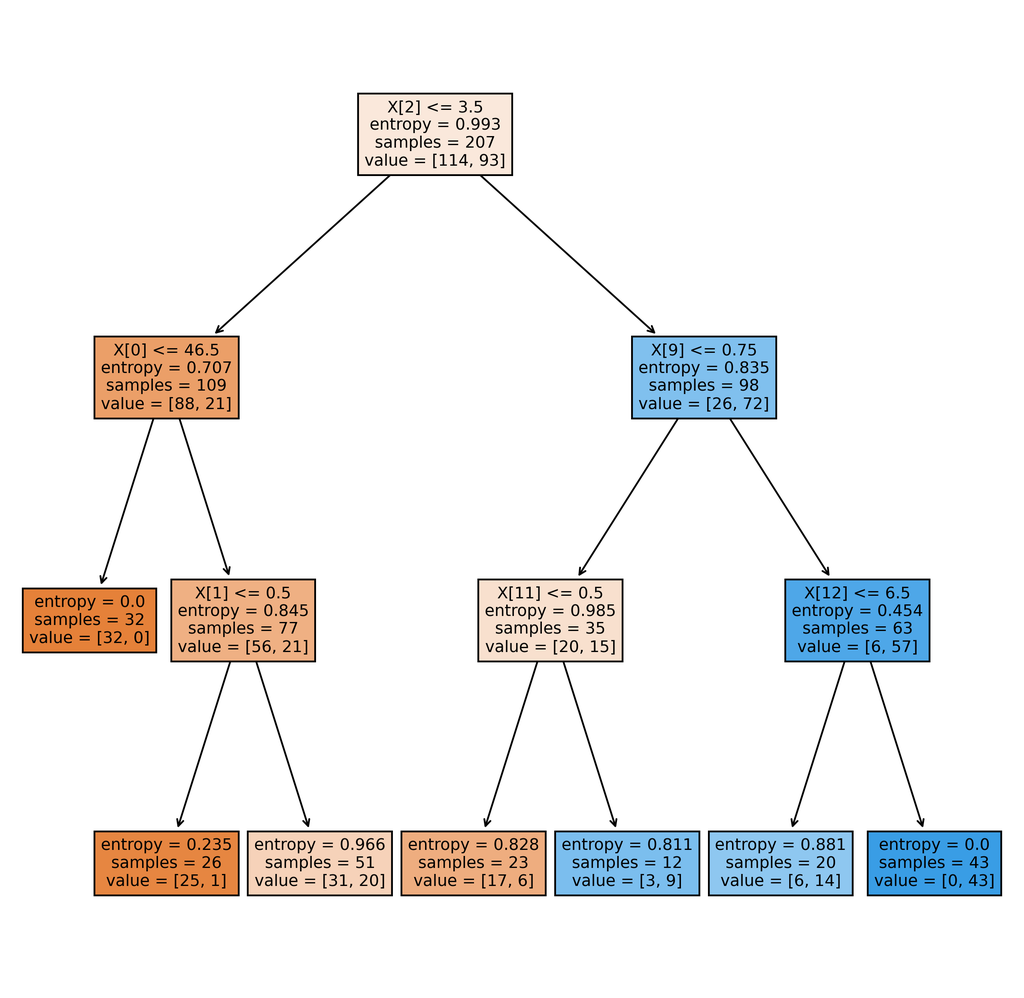

```python
# we visualize the improved tree

fig, axes = plt.subplots(nrows = 1,ncols = 1,figsize = (10,10), dpi=300)
tree.plot_tree(model.best_estimator_, filled=True,max_depth=3)
```

#### We ended up with a tree with a higher accuracy and limited the size of the tree to avoid overfitting

Note: we could keep improving this algorithm with more sophisticated methods, such as **Random Forests**, but the objective of this exercise was to only work with Decision Trees